# Machine Learning class: session 2

Kevin Vervier

August 1, 2016

# Session 1 debriefing + homework

First, we need to load the data we processed during the last session:

```r
data <- read.csv('../../data/iris_processed.csv')
```

- Plot the sepal length as a function of iris species (*Hint*: boxplot),

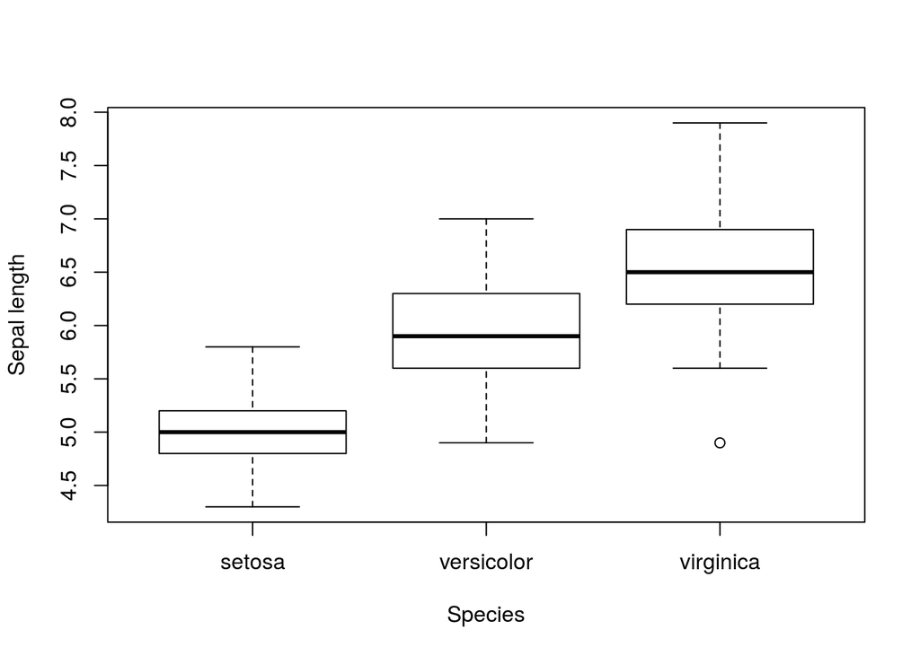

```r
boxplot(sepal_length ~ species, data = data,xlab='Species',ylab='Sepal length')
```

```r
# CLearly, there is an effect.
```

- Add dummy (binary) variables to iris dataset that represent species (*Hint*: 2 of them are enough),

```r
# initiate
dummy = matrix(0,nrow=nrow(data),ncol=2)
colnames(dummy) = c('isSetosa','isVsericolor')
dummy[which(data$species == 'setosa'),1] = 1
dummy[which(data$species == 'versicolor'),2] = 1
# virginica will be encoded by 0 in both columns

#even if dummy variables are binary, we may want to scale them
dummy = scale(dummy,center = TRUE,scale=TRUE)

#merge both datasets
data_with_dummy = cbind(data,dummy)
#remove species column (redundant)
data_with_dummy$species = NULL
```

- Fit linear model on this new data set (*Hint*: using cross-validation and regularization).

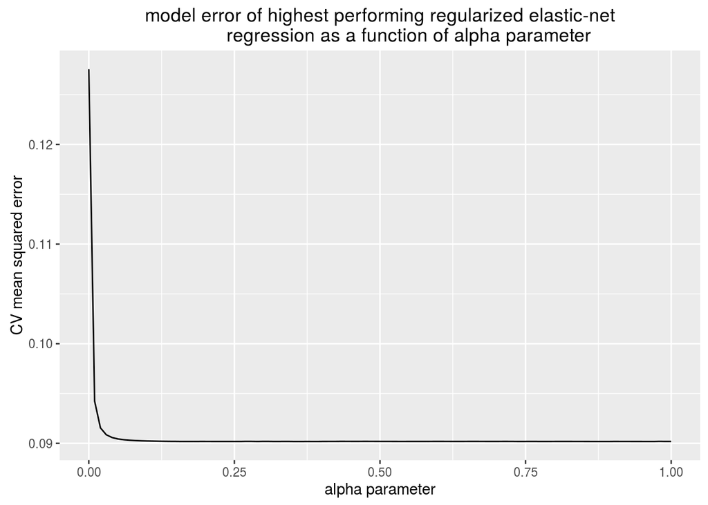

```r
# Code for a cross-validation evaluation
set.seed(42) # fix random seed for reproducible results
# Number of folds/rounds
nfolds = 10
# Generate random index
idx = sample(1:nfolds,nrow(data_with_dummy),replace=TRUE)

#define alpha parameter
alphas <- seq(from = 0, to = 1, by = 0.01)

#define output
mses <- rep(0,length(alphas))

#loop over alpha values
for(i in 1:length(alphas)){
   # cv.glmnet function does the CV loop for the different folds
  cvfits <- cv.glmnet(x=as.matrix(data_with_dummy[,-1]), y=data_with_dummy[,1], alpha=alphas[i], nfolds=nfolds,foldid=idx) # for a given alpha, lambda is optimized inside cv.glmnet
  preds.regul = predict(cvfits, newx = as.matrix(data_with_dummy[,-1]), s = "lambda.min")
  mses[i] <- mean((data_with_dummy[,1] - preds.regul)^2)
}
this <- data.frame(mse=mses, alpha=alphas)

plot1 <- ggplot(this, aes(x=alpha, y=mse)) +
  geom_line() +
  ylab("CV mean squared error") +
  xlab("alpha parameter") +
  ggtitle("model error of highest performing regularized elastic-net
           regression as a function of alpha parameter")
plot1
```

```r
#get best model among alpha-range
best.alpha = alphas[tail(which(mses == min(mses)),1)]
#retrain model with best_alpha
cvfits <- cv.glmnet(x=as.matrix(data_with_dummy[,-1]), y=data_with_dummy[,1], alpha=best.alpha, nfolds=nfolds,foldid=idx)

# print best parameters pair
cat('Best alpha:',best.alpha,' and best lambda:',cvfits$lambda.min,'\n')
```

```
## Best alpha: 0.36  and best lambda: 0.0004616793
```

```r
#get preds for the best (alpha,lambda) pair
preds.regul = predict(cvfits, newx = as.matrix(data_with_dummy[,-1]), s = "lambda.min")
#Check the best model content
coef(cvfits, s = "lambda.min")
```

```
## 6 x 1 sparse Matrix of class "dgCMatrix"
##                       1
## (Intercept)   1.6211825
## sepal_width   0.5074979
## petal_length  0.8128158
## petal_width  -0.3193977
## isSetosa      0.4469454
## isVsericolor  0.1310090
```

```r
# Simple Linear Model trained with all the features
cor(data_with_dummy[,1],preds.regul)
```

```
##              1
## [1,] 0.9314509
```

```r
#NB: session 1 best model achieved cor = 0.926916

# Regularized Model
mean((data_with_dummy[,1] - preds.regul)^2)
```

```
## [1] 0.09018419
```

```r
#NB: session 1 best model achieved mse = 0.09592393
```

This concludes Homework 1. Now, Session 2 is about to start !

# Classification methods

- Talking about classification refers to having qualitative response $Y$ that belongs to a finite set of **labels/classes**.
- Why not Liner Regression ?
  - Example: Suppose that we are trying to predict the medical condition of a patient in the emergency room on the basis of her symptoms, where there are only three possible diagnoses: *stroke*, *drug overdose*, and *epileptic seizure*. We could consider encoding these values as a quantitative response variable, $Y$, as follows:

$\left\{ \begin{array}{ll} 1 & \text{ if stroke,} \\ 2 & \text{ if drug overdose,} \\ 3 & \text{ if epileptic seizure} \end{array}\right.$

Using this coding, least squares could be used to fit a linear regression model. But unfortunately, this coding implies an ordering on the outcomes. (*Quizz*) So why linear regression is not a good idea here ?

So what are the alternative solutions for classification ? There is two ways of thinking in classification: do you want to predict the class label and/or do you want a estimated probability of this class prediction ?

In the following sections, we will review standard classification algorithms with their own strategy/decision rule. For demonstration purpose, we will apply them to the `iris` data set in its standard use: **Is it possible to predict to which species a new flower belongs ?**

However, we will keep things simple by considering only the first two classes $\Rightarrow$ binary classification.

If your data contains more than two classes, there is multiple ways to extend binary classification to multiclass classification (One-versus-All, One-versus-One, …). Most of the time, there is additional parameters to provide when you call the function, but the function name remains the same (cf function doc).

```r
#only keep the first 2 classes
data = data[which(data$species == 'setosa' | data$species == 'versicolor'),]
# re-define the levels of species column (useful ?)
data$species = factor(data$species)
```

## Logistic regression (Chapter 4.3)

- Variation of the Linear Regression for classification purpose.
- Rather than modeling the response $Y$ directly, logistic regression models the probability (from 0 to 1) that $Y$ belongs to a particular category.

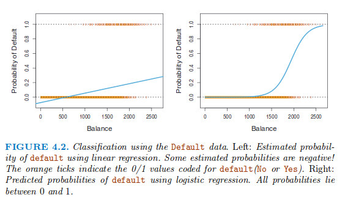

- Here, we use a similar framework to linear regression, called Generalized Linear Model (`glmnet`):

```r
fit <- glmnet(x=as.matrix(data[,-1]), y=data[,1],family="binomial",alpha = 0.5)
#see coefficients for 1 model
coef(fit)[,7]
```

```
##  (Intercept) sepal_length  sepal_width petal_length  petal_width
##   -0.9171509    0.0000000    0.0000000    0.1935953    0.4644622
```

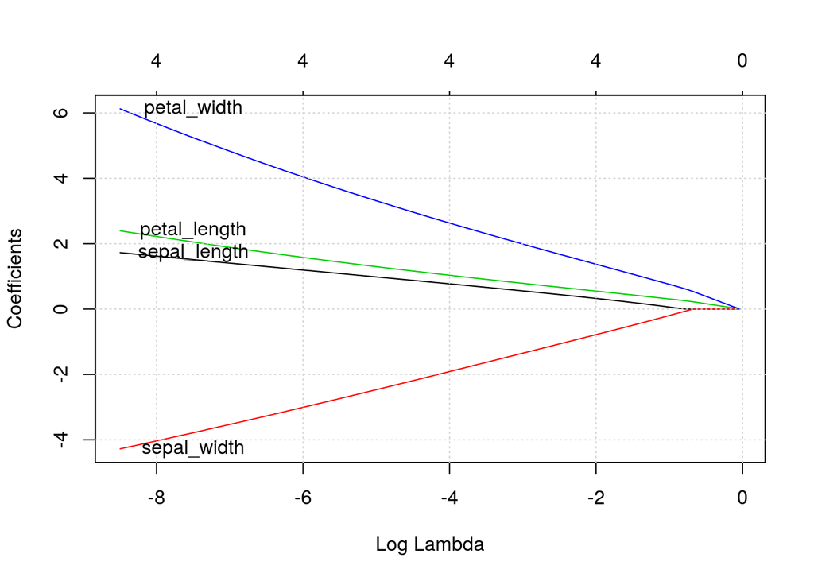

```r
# see regularization path
plot(fit,xvar="lambda")
grid()
#add variable name
L <- length(fit$lambda)
x <- log(fit$lambda[L])
y <- fit$beta[, L]
labs <- names(y)
text(x+1, y, labels=labs)
```

## Support Vector Machine (Chapter 9)

- Try to find the best linear separation between classes.
- It is unlikely that your real-world data are perfectly separable.
- SVMs introduce the concept of margin between different classes and cast it in an regularization framework.

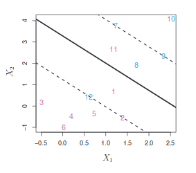

**Source**: An Introduction to Statistical Learning with Applications in R (9.2.2).

- There is different `R` packages for SVM, that rely on subtle variations around the main concept.
- In this tutorial, we will use `LiblineaR` package, where you may want to optimize at least 1 parameter:
  - `cost` determines the trade-off between the margin fit and the misclassification tolerance (high value $\Rightarrow$ more tolerance),
  - Advanced: `type` parameter determines the loss and regularization functions. you can for instance do logistic regression, or use a Lasso,
  - Advanced: it is possible to use ‘kernel’ transformation, when facing data not separable with a linear model (section 9.3.1).

```r
m <- LiblineaR(data=as.matrix(data[,-1]), target=data[,1],cost = 1, type = 2)
```

## k-nearest neighbours

returns label based on neighbors labels

## Classification performance measures

**Meditation before concluding…**

Choose your data for the last session. If you have no idea on a candidate, we could pick one based on specific points you want to work on.

# Session 3: Your turn !

Here, the idea is to apply the different classification techniques to a new data set, and compare them using the evaluation framework we described in Session 1 (parameter optimization, cross-validation, etc.)

Hints: * Whatever the approach you use, your prediction step will often use the `predict` function.

# Ressources

[(1) Hastie and Tibshirani Online course](http://www.r-bloggers.com/in-depth-introduction-to-machine-learning-in-15-hours-of-expert-videos/)

[An Introduction to Statistical Learning with Applications in R](http://www-bcf.usc.edu/~gareth/ISL/ISLR%20Sixth%20Printing.pdf)

[Introduction to ML with knn applied on iris data](http://www.datacamp.com/community/tutorials/machine-learning-in-r)